# Natural Language Processing - Twitter Analysis

## Problem Statement

### Context

Twitter's massive user base of 330 million monthly active users presents a direct avenue for businesses to connect with a broad audience. However, the vast amount of information on the platform makes it challenging for brands to swiftly detect negative social mentions that may impact their reputation. To tackle this, sentiment analysis has become a crucial tool in social media marketing, enabling businesses to monitor emotions in conversations, understand customer sentiments, and gain insights to stay ahead in their industry.

That's why sentiment analysis/classification, which involves monitoring emotions in conversations on social media platforms, has become a key strategy in social media marketing.

### Objective

The aim of this project is to build a sentimental analysis model that classify the sentiment of tweets into the positive, neutral & negative.

### Data Dictionary

- tweet_id - A unique identifier for each tweet
- airline_sentiment - The sentiment label of the tweet, such as positive, negative, or neutral
- airline_sentiment_confidence - The confidence level associated with the sentiment label
- negativereason - A category indicating the reason for negative sentiment
- negativereason_confidence - The confidence level associated with the negative reason

*airline - The airline associated with the tweet

- airline_sentiment_gold - Gold standard sentiment label
- name - The username of the tweet author
- retweet_count - The number of times the tweet has been retweeted
- text - The actual text content of the tweet.
- tweet_coord - Coordinates of the tweet
- tweet_created - The timestamp when the tweet was created
- tweet_location - The location mentioned in the tweet
- user_timezone - The timezone of the tweet author

## Importing necessary libraries

```python
#import libraries below
import numpy as np
import random
import pandas as pd
import matplotlib.pyplot as plt
import seaborn as sns

from collections import Counter                                                 # counter for key-value pairs in an object
!pip install contractions
import re, string, unicodedata                                                  # import text preprocessing libraries
import contractions                                                             # import contractions library
from bs4 import BeautifulSoup                                                   # import BeautifulSoup
!pip install wordcloud
from wordcloud import WordCloud, STOPWORDS, ImageColorGenerator                 # import wordcloud of a corpus, stopwords
!pip install nltk
import nltk                                                                     # import nltk library
from nltk.corpus import stopwords                                               # import nltk stopwords
from nltk.tokenize import word_tokenize, sent_tokenize                          # import Tokenizer
from nltk.stem.wordnet import WordNetLemmatizer                                 # import Lemmatizer
from nltk.stem.porter import PorterStemmer                                      # import Stemmer

from sklearn.feature_extraction.text import CountVectorizer                     # import CountVectorizer
from sklearn.feature_extraction.text import TfidfVectorizer                     # import TF-IDF

from sklearn.model_selection import train_test_split
from sklearn.model_selection import KFold , StratifiedKFold, cross_val_score
from sklearn.metrics import accuracy_score

from sklearn.ensemble import RandomForestClassifier                             # import Random Forest Classifier
from sklearn.metrics import classification_report                               # import classification report
from sklearn.model_selection import cross_val_score



# download stopwords
nltk.download('punkt')
nltk.download('wordnet')
```

```
True
```

```python
# remove warnings
import warnings
warnings.filterwarnings('ignore')

# format numeric data for easier readability
pd.set_option(
    "display.float_format", lambda x: "%.2f" % x
)  # to display numbers rounded to 2 decimal places
```

## Loading the dataset

```python
# Mount Google drive to access the dataset only if you are using Google Colab
```

```python
# read the data
tweets=pd.read_csv('tweets.csv')
```

## Data Overview

The initial steps to get an overview of any dataset is to:

- Observe the first few rows of the dataset, to check whether the dataset has been loaded properly or not
- Get information about the number of rows and columns in the dataset
- Find out the data types of the columns to ensure that data is stored in the preferred format and the value of each property is as expected.

```python
df=tweets.copy()
```

```python
df.shape
```

```
(14640, 15)
```

```python
# show first five rows of data
df.head(n=5)
```

|  | tweet_id | airline_sentiment | airline_sentiment_confidence | negativereason | negativereason_confidence | airline | airline_sentiment_gold | name | negativereason_gold | retweet_count | text | tweet_coord | tweet_created | tweet_location | user_timezone |
| --- | --- | --- | --- | --- | --- | --- | --- | --- | --- | --- | --- | --- | --- | --- | --- |
| 0 | 570306133677760513 | neutral | 1.00 | NaN | NaN | Virgin America | NaN | cairdin | NaN | 0 | @VirginAmerica What @dhepburn said. | NaN | 2015-02-24 11:35:52 -0800 | NaN | Eastern Time (US & Canada) |
| 1 | 570301130888122368 | positive | 0.35 | NaN | 0.00 | Virgin America | NaN | jnardino | NaN | 0 | @VirginAmerica plus you've added commercials t... | NaN | 2015-02-24 11:15:59 -0800 | NaN | Pacific Time (US & Canada) |
| 2 | 570301083672813571 | neutral | 0.68 | NaN | NaN | Virgin America | NaN | yvonnalynn | NaN | 0 | @VirginAmerica I didn't today... Must mean I n... | NaN | 2015-02-24 11:15:48 -0800 | Lets Play | Central Time (US & Canada) |
| 3 | 570301031407624196 | negative | 1.00 | Bad Flight | 0.70 | Virgin America | NaN | jnardino | NaN | 0 | @VirginAmerica it's really aggressive to blast... | NaN | 2015-02-24 11:15:36 -0800 | NaN | Pacific Time (US & Canada) |
| 4 | 570300817074462722 | negative | 1.00 | Can't Tell | 1.00 | Virgin America | NaN | jnardino | NaN | 0 | @VirginAmerica and it's a really big bad thing... | NaN | 2015-02-24 11:14:45 -0800 | NaN | Pacific Time (US & Canada) |

```python
# show last five rows of data
df.tail()
```

|  | tweet_id | airline_sentiment | airline_sentiment_confidence | negativereason | negativereason_confidence | airline | airline_sentiment_gold | name | negativereason_gold | retweet_count | text | tweet_coord | tweet_created | tweet_location | user_timezone |
| --- | --- | --- | --- | --- | --- | --- | --- | --- | --- | --- | --- | --- | --- | --- | --- |
| 14635 | 569587686496825344 | positive | 0.35 | NaN | 0.00 | American | NaN | KristenReenders | NaN | 0 | @AmericanAir thank you we got on a different f... | NaN | 2015-02-22 12:01:01 -0800 | NaN | NaN |
| 14636 | 569587371693355008 | negative | 1.00 | Customer Service Issue | 1.00 | American | NaN | itsropes | NaN | 0 | @AmericanAir leaving over 20 minutes Late Flig... | NaN | 2015-02-22 11:59:46 -0800 | Texas | NaN |
| 14637 | 569587242672398336 | neutral | 1.00 | NaN | NaN | American | NaN | sanyabun | NaN | 0 | @AmericanAir Please bring American Airlines to... | NaN | 2015-02-22 11:59:15 -0800 | Nigeria,lagos | NaN |
| 14638 | 569587188687634433 | negative | 1.00 | Customer Service Issue | 0.67 | American | NaN | SraJackson | NaN | 0 | @AmericanAir you have my money, you change my ... | NaN | 2015-02-22 11:59:02 -0800 | New Jersey | Eastern Time (US & Canada) |
| 14639 | 569587140490866689 | neutral | 0.68 | NaN | 0.00 | American | NaN | daviddtwu | NaN | 0 | @AmericanAir we have 8 ppl so we need 2 know h... | NaN | 2015-02-22 11:58:51 -0800 | dallas, TX | NaN |

```python
# show summary of dataset
df.info()
```

```
<class 'pandas.core.frame.DataFrame'>
RangeIndex: 14640 entries, 0 to 14639
Data columns (total 15 columns):
 #   Column                        Non-Null Count  Dtype
---  ------                        --------------  -----
 0   tweet_id                      14640 non-null  int64
 1   airline_sentiment             14640 non-null  object
 2   airline_sentiment_confidence  14640 non-null  float64
 3   negativereason                9178 non-null   object
 4   negativereason_confidence     10522 non-null  float64
 5   airline                       14640 non-null  object
 6   airline_sentiment_gold        40 non-null     object
 7   name                          14640 non-null  object
 8   negativereason_gold           32 non-null     object
 9   retweet_count                 14640 non-null  int64
 10  text                          14640 non-null  object
 11  tweet_coord                   1019 non-null   object
 12  tweet_created                 14640 non-null  object
 13  tweet_location                9907 non-null   object
 14  user_timezone                 9820 non-null   object
dtypes: float64(2), int64(2), object(11)
memory usage: 1.7+ MB
```

- 7 of the 15 columns contain missing data
- However, fortunately, these columns will only be useful during exploratory data analysis, rather than for building our model(s)

```python
# convert all columns with dtype object into category to save memory
for col in df.columns[df.dtypes=='object']:
    df[col] = df[col].astype('category')
```

```python
# convert tweet_id into a category to save memory
df['tweet_id'] = df['tweet_id'].astype('category')
```

```python
# Option 1: Remove timezone information
df['tweet_created'] = pd.to_datetime(df['tweet_created'])
df['tweet_created'] = df['tweet_created'].dt.tz_localize(None)
df['tweet_created'] = df['tweet_created'].astype('datetime64[ns]')
```

```python
# show summary of dataset after conversion
df.info()
```

```
<class 'pandas.core.frame.DataFrame'>
RangeIndex: 14640 entries, 0 to 14639
Data columns (total 15 columns):
 #   Column                        Non-Null Count  Dtype
---  ------                        --------------  -----
 0   tweet_id                      14640 non-null  category
 1   airline_sentiment             14640 non-null  category
 2   airline_sentiment_confidence  14640 non-null  float64
 3   negativereason                9178 non-null   category
 4   negativereason_confidence     10522 non-null  float64
 5   airline                       14640 non-null  category
 6   airline_sentiment_gold        40 non-null     category
 7   name                          14640 non-null  category
 8   negativereason_gold           32 non-null     category
 9   retweet_count                 14640 non-null  int64
 10  text                          14640 non-null  category
 11  tweet_coord                   1019 non-null   category
 12  tweet_created                 14640 non-null  datetime64[ns]
 13  tweet_location                9907 non-null   category
 14  user_timezone                 9820 non-null   category
dtypes: category(11), datetime64[ns](1), float64(2), int64(1)
memory usage: 2.3 MB
```

## Exploratory Data Analysis

- EDA is an important part of any project involving data.
- It is important to investigate and understand the data better before building a model with it.
- A few questions have been mentioned below which will help you approach the analysis in the right manner and generate insights from the data.
- A thorough analysis of the data, in addition to the questions mentioned below, should be done.

**Questions**:

- What is the percentage of tweets for each airline?
- What is the distribution of sentiments across all the tweets?
- What is the distribution of sentiments for each airline?
- What does the plot of negative reasons indicate?
- How does a wordcloud appear for negative tweets?
- How does a wordcloud appear for positive tweets?
- What are insights observed from EDA?

```python
# show summary of all numerical variables
df.describe().T
```

|  | count | mean | min | 25% | 50% | 75% | max | std |
| --- | --- | --- | --- | --- | --- | --- | --- | --- |
| airline_sentiment_confidence | 14640.00 | 0.90 | 0.34 | 0.69 | 1.00 | 1.00 | 1.00 | 0.16 |
| negativereason_confidence | 10522.00 | 0.64 | 0.00 | 0.36 | 0.67 | 1.00 | 1.00 | 0.33 |
| retweet_count | 14640.00 | 0.08 | 0.00 | 0.00 | 0.00 | 0.00 | 44.00 | 0.75 |
| tweet_created | 14640 | 2015-02-21 11:33:24.781216 | 2015-02-16 23:36:05 | 2015-02-19 15:54:05.750000128 | 2015-02-22 04:44:35.500000 | 2015-02-23 08:04:11 | 2015-02-24 11:53:37 | NaN |

- Of the 14,640 tweets, the tweet with maximum number of retweets was only 44. This signifies that none of these tweets were from highly influential individuals or pertained to an event with a significant amount of engagement (i.e., a "viral" moment).

```python
# show summary of all categorical variables
df.describe(include=['category']).T
```

|  | count | unique | top | freq |
| --- | --- | --- | --- | --- |
| tweet_id | 14640 | 14485 | 570281470507352064 | 2 |
| airline_sentiment | 14640 | 3 | negative | 9178 |
| negativereason | 9178 | 10 | Customer Service Issue | 2910 |
| airline | 14640 | 6 | United | 3822 |
| airline_sentiment_gold | 40 | 3 | negative | 32 |
| name | 14640 | 7701 | JetBlueNews | 63 |
| negativereason_gold | 32 | 13 | Customer Service Issue | 12 |
| text | 14640 | 14427 | @united thanks | 6 |
| tweet_coord | 1019 | 832 | [0.0, 0.0] | 164 |
| tweet_location | 9907 | 3081 | Boston, MA | 157 |
| user_timezone | 9820 | 85 | Eastern Time (US & Canada) | 3744 |

```python
# show summary of datetime variable
df.describe(include=['datetime']).T
```

|  | count | mean | min | 25% | 50% | 75% | max |
| --- | --- | --- | --- | --- | --- | --- | --- |
| tweet_created | 14640 | 2015-02-21 11:33:24.781216 | 2015-02-16 23:36:05 | 2015-02-19 15:54:05.750000128 | 2015-02-22 04:44:35.500000 | 2015-02-23 08:04:11 | 2015-02-24 11:53:37 |

```python
# show number of tweets by day
by_date = df.groupby(pd.Grouper(key='tweet_created', axis=0, freq='D')).count()['tweet_id']
print(by_date)
```

```
tweet_created
2015-02-16       4
2015-02-17    1408
2015-02-18    1344
2015-02-19    1376
2015-02-20    1500
2015-02-21    1557
2015-02-22    3079
2015-02-23    3028
2015-02-24    1344
Freq: D, Name: tweet_id, dtype: int64
```

```python
# function to create labeled barplots

def labeled_barplot(data, feature, hue=None, perc=False, n=None):
    """
    Barplot with percentage at the top

    data: dataframe
    feature: dataframe column
    hue: whether to groupby another dataframe column
    perc: whether to display percentages instead of count (default is False)
    n: displays the top n category levels (default is None, i.e., display all levels)
    """

    total = len(data[feature])  # length of the column

    ax = sns.countplot(
        data=data,
        x=feature,
        hue=hue,
        palette='viridis',
        order = data[feature].value_counts().index,
    )

    for p in ax.patches:
        if perc == True:
            label = "{:.1f}%".format(
                100 * p.get_height() / total
            )  # percentage of each class of the category
        else:
            label = p.get_height()  # count of each level of the category

        x = p.get_x() + p.get_width() / 2  # width of the plot
        y = p.get_height()  # height of the plot

        ax.annotate(
            label,
            (x, y),
            ha="center",
            va="center",
            size=12,
            xytext=(0, 5),
            textcoords="offset points"
        )  # annotate the percentage

    plt.show()  # show the plot
```

```python
# import the figure size for the visualizations
from matplotlib import rcParams
```

### Distribution of sentiment across all the tweets

```python
# show number of tweets by sentiment
df.airline_sentiment.value_counts()
```

```
airline_sentiment
negative    9178
neutral     3099
positive    2363
Name: count, dtype: int64
```

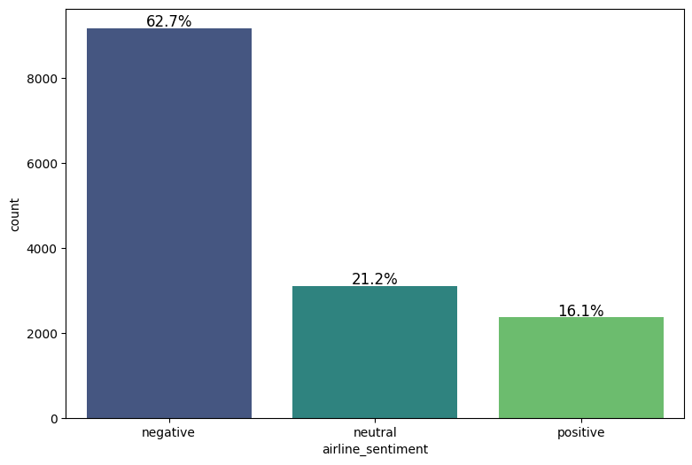

```python
# create labled barplot for number of tweets by sentiment
rcParams['figure.figsize'] = 9,6
labeled_barplot(df,'airline_sentiment',perc=True)
```

- There are **~4 times** as many tweets with negative sentiment as positive sentiment
- There are ~3 times as many tweets with negative sentiment as neutral sentiment
- This indicates that our classification model(s) will be biased by this class imbalance

### Distribution of all tweets among each airline

```python
df['airline'].value_counts()
```

```
airline
United            3822
US Airways        2913
American          2759
Southwest         2420
Delta             2222
Virgin America     504
Name: count, dtype: int64
```

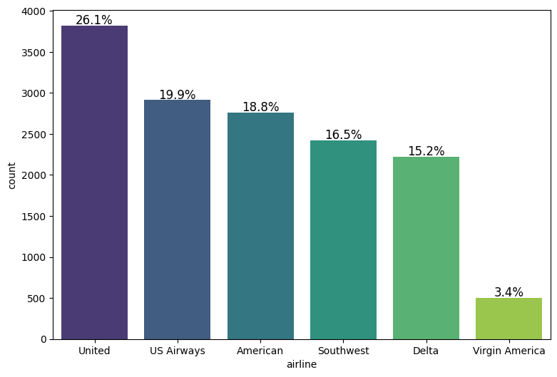

```python
# create labled barplot for number of tweets by airline
rcParams['figure.figsize'] = 9,6
labeled_barplot(df,'airline',perc=True)
```

- Tweets concerning United Airlines received the most tweets (~26.1% of all tweets)
- Tweets concerning Virigin America received the fewest tweets (~3.4% of all tweets)
- The number of tweets is likley dependent on the size of the carrier (i.e., number of flights per day)
- A potential key performance metric (KPM) of customer service could be the ratio of positive to negative tweets per enplaned passenger

### Distribution of sentiment of tweets for each airline

```python
df.groupby('airline')['airline_sentiment'].value_counts()
```

```
airline         airline_sentiment
American        negative             1960
                neutral               463
                positive              336
Delta           negative              955
                neutral               723
                positive              544
Southwest       negative             1186
                neutral               664
                positive              570
US Airways      negative             2263
                neutral               381
                positive              269
United          negative             2633
                neutral               697
                positive              492
Virgin America  negative              181
                neutral               171
                positive              152
Name: count, dtype: int64
```

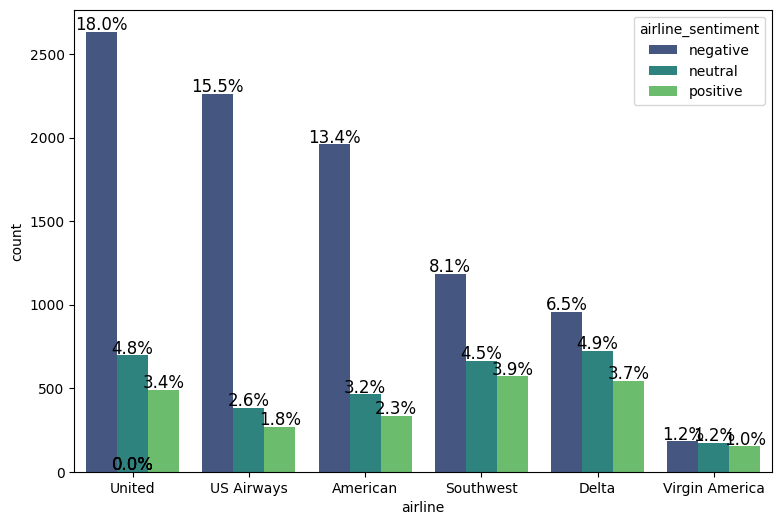

```python
# create labled barplot for number of tweets by airline and sentiment
rcParams['figure.figsize'] = 9,6
labeled_barplot(df,'airline','airline_sentiment',perc=True)
```

### Distribution of all the negative reasons.

```python
df.negativereason.value_counts()
```

```
negativereason
Customer Service Issue         2910
Late Flight                    1665
Can't Tell                     1190
Cancelled Flight                847
Lost Luggage                    724
Bad Flight                      580
Flight Booking Problems         529
Flight Attendant Complaints     481
longlines                       178
Damaged Luggage                  74
Name: count, dtype: int64
```

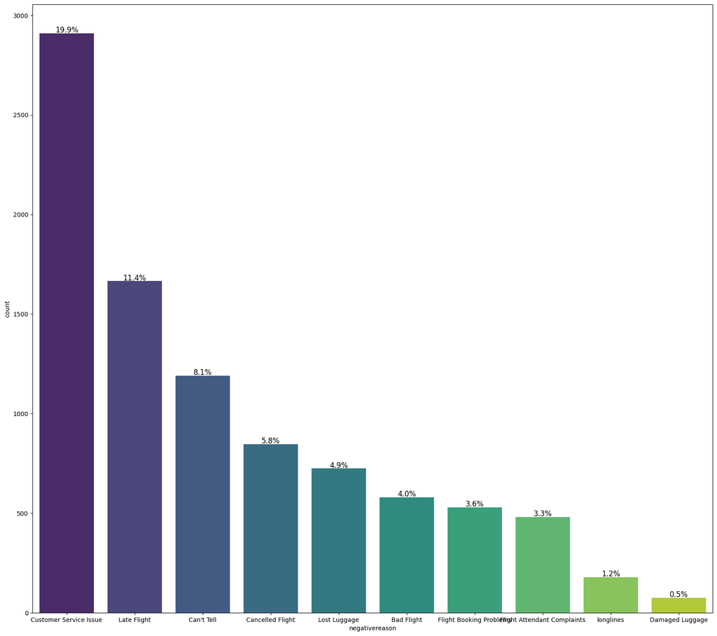

```python
# create labled barplot for number of negative reasons
rcParams['figure.figsize'] = 20,18
labeled_barplot(df,'negativereason',perc=True)
```

- The top five reasons given for a negative tweet are:
  - Customer Service Issue
  - Late Flight
  - Can't Tell
  - Cancelled Flight
  - Lost Luggage

### word cloud graph of tweets for positive and negative sentiment

```python
def wordcloud(tweets):
  words = ' '.join(tweets['text'])
  cleaned_word = " ".join([word for word in words.split()
                            if 'http' not in word
                                and not word.startswith('@')
                                and word != 'RT'
                            ])
  wordcloud = WordCloud(stopwords=STOPWORDS,
                      width=3000,
                      height=2500
                     ).generate(cleaned_word)
  plt.figure(1,figsize=(12, 12))
  plt.imshow(wordcloud)
  plt.axis('off')
  plt.show()
```

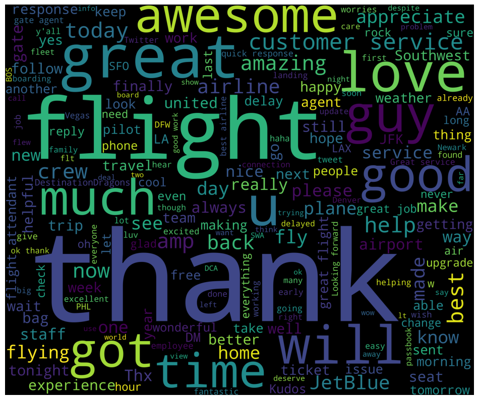

```python
# create word cloud for positive tweets
pos_tweets = df[df['airline_sentiment']=='positive']
wordcloud(pos_tweets)
```

- As expected, words like thank, awesome, love, great, amazing were the most commonly used in positive tweets

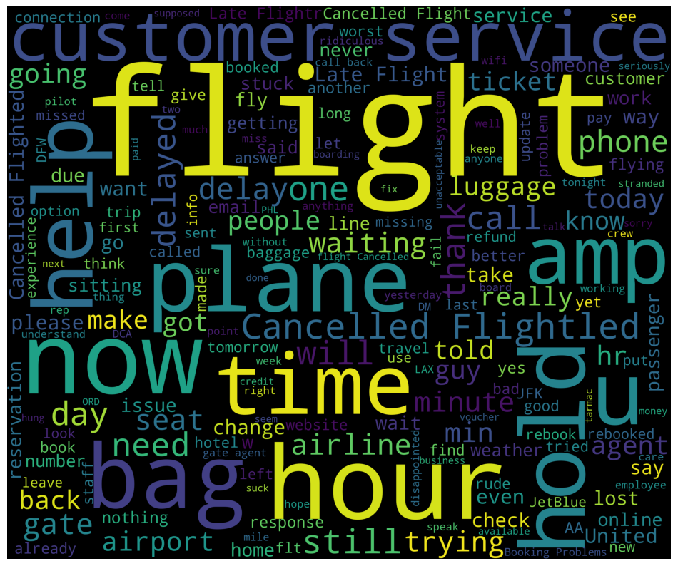

```python
# create word cloud for negative tweets
neg_tweets = df[df['airline_sentiment']=='negative']
wordcloud(neg_tweets)
```

- Flight is a very common word in both positive and negative tweets, indicating that this word will likely not contribute to a classification model
- As expected from the negative reasons shown above, words like bag, time, now, cancelled, and plane were the most commonly used in negative tweets

## Data Preparation for Modeling

- Drop all unnecessary columns
- Remove html tags
- Replace contractions in string(e.g. replace I'm --> I am) and so on.\
- Remove numbers
- Tokenization
- To remove Stopwords
- Lemmatized data

```python
column_list = df.columns.to_list()
```

```python
# identify columns used for model building
columns = ['text','airline_sentiment']
```

```python
# identify columns to be dropped
drop_columns = [col for col in column_list if col not in columns]
print(drop_columns)
```

```
['tweet_id', 'airline_sentiment_confidence', 'negativereason', 'negativereason_confidence', 'airline', 'airline_sentiment_gold', 'name', 'negativereason_gold', 'retweet_count', 'tweet_coord', 'tweet_created', 'tweet_location', 'user_timezone']
```

```python
# drop all other columns except “text” and “airline_sentiment”
df_model = df.drop(columns = drop_columns)
```

```python
# confirm new shape of the dataset
df_model.shape
```

```
(14640, 2)
```

```python
pd.set_option('display.max_colwidth', None) # Display full dataframe information (non-turncated text column.)
#print head of new dataset
df_model.head()
```

|  | airline_sentiment | text |
| --- | --- | --- |
| 0 | neutral | @VirginAmerica What @dhepburn said. |
| 1 | positive | @VirginAmerica plus you've added commercials to the experience... tacky. |
| 2 | neutral | @VirginAmerica I didn't today... Must mean I need to take another trip! |
| 3 | negative | @VirginAmerica it's really aggressive to blast obnoxious "entertainment" in your guests' faces &amp; they have little recourse |
| 4 | negative | @VirginAmerica and it's a really big bad thing about it |

```python
#remove the html tags
def strip_html(text):
    soup = BeautifulSoup(text, "html.parser")
    return soup.get_text()

#expand the contractions
def replace_contractions(text):
    """Replace contractions in string of text"""
    return contractions.fix(text)

#remove the numericals present in the text
def remove_numbers(text):
  text = re.sub(r'\d+', '', text)
  return text

# remove the url's present in the text
def remove_url(text):
    text = re.sub('http[s]?://(?:[a-zA-Z]|[0-9]|[$-_@.&+]|[!*\(\),]|(?:%[0-9a-fA-F][0-9a-fA-F]))+','',text)
    return text

# remove the mentions in the tweets
def remove_mention(text):
    text = re.sub(r'@\w+','',text)
    return text

def clean_text(text):
    text = strip_html(text)
    text = replace_contractions(text)
    text = remove_numbers(text)
    text = remove_url(text)
    text = remove_mention(text)
    return text
df_model['text'] = df_model['text'].apply(lambda x: clean_text(x))
df_model.head()
```

|  | airline_sentiment | text |
| --- | --- | --- |
| 0 | neutral | What said. |
| 1 | positive | plus you have added commercials to the experience... tacky. |
| 2 | neutral | I did not today... Must mean I need to take another trip! |
| 3 | negative | it is really aggressive to blast obnoxious "entertainment" in your guests' faces & they have little recourse |
| 4 | negative | and it is a really big bad thing about it |

```python
#tokenization

df_model['text'] = df_model.apply(lambda row: nltk.word_tokenize(row['text']), axis=1) # tokenization of data
df_model.head()
```

|  | airline_sentiment | text |
| --- | --- | --- |
| 0 | neutral | [What, said, .] |
| 1 | positive | [plus, you, have, added, commercials, to, the, experience, ..., tacky, .] |
| 2 | neutral | [I, did, not, today, ..., Must, mean, I, need, to, take, another, trip, !] |
| 3 | negative | [it, is, really, aggressive, to, blast, obnoxious, ``, entertainment, '', in, your, guests, ', faces, &, they, have, little, recourse] |
| 4 | negative | [and, it, is, a, really, big, bad, thing, about, it] |

```python
import nltk
nltk.download('stopwords')
```

```
True
```

```python
stopwords = stopwords.words('english')
custom_remove_list = ['flight']
stopwords = list(set(stopwords)) + custom_remove_list
lemmatizer = WordNetLemmatizer()

# remove the non-ASCII characters
def remove_non_ascii(words):
    """Remove non-ASCII characters from list of tokenized words"""
    new_words = []
    for word in words:
        new_word = unicodedata.normalize('NFKD', word).encode('ascii', 'ignore').decode('utf-8', 'ignore')
        new_words.append(new_word)
    return new_words

# convert all characters to lowercase
def to_lowercase(words):
    """Convert all characters to lowercase from list of tokenized words"""
    new_words = []
    for word in words:
        new_word = word.lower()
        new_words.append(new_word)
    return new_words

# remove the hashtags
def remove_hash(text):
   """Remove hashtags from list of tokenized words"""
   new_words = []
   for word in words:
     new_word = re.sub(r'#\w+','',word)
     if new_word != '':
       new_words.append(new_word)
   return new_words

# remove the punctuations
def remove_punctuation(words):
    """Remove punctuation from list of tokenized words"""
    new_words = []
    for word in words:
        new_word = re.sub(r'[^\w\s]', '', word)
        if new_word != '':
            new_words.append(new_word)
    return new_words

# remove the stop words
def remove_stopwords(words):
    """Remove stop words from list of tokenized words"""
    new_words = []
    for word in words:
        if word not in stopwords:
            new_words.append(word)
    return new_words

# lemmatize the words
def lemmatize_list(words):
    new_words = []
    for word in words:
      new_words.append(lemmatizer.lemmatize(word, pos='v'))
    return new_words

def normalize(words):
    words = remove_non_ascii(words)
    words = to_lowercase(words)
    words = remove_punctuation(words)
    words = remove_stopwords(words)
    words = lemmatize_list(words)
    return ' '.join(words)

df_model['text'] = df_model.apply(lambda row: normalize(row['text']), axis=1)
df_model.head()
```

|  | airline_sentiment | text |
| --- | --- | --- |
| 0 | neutral | say |
| 1 | positive | plus add commercials experience tacky |
| 2 | neutral | today must mean need take another trip |
| 3 | negative | really aggressive blast obnoxious entertainment guests face little recourse |
| 4 | negative | really big bad thing |

## Model Building

### Using countvectorizer

- Intialize countvectorizer and use it for vectorization
- Store Independent and Dependent variables
- Split the data into train and test
- Build a Random Forest model on train data
- Use Cross validation to validate the score and to find optimal n_estimators
- Plot the misclassification error for each of estimators
- Test the model on testing data
- Plot the Confusion matrix

```python
# set independent variable for classification model
targets = sorted(df_model.airline_sentiment.unique().to_list())
print(targets)
```

```
['negative', 'neutral', 'positive']
```

```python
# set the max number of features at 1000
count_vec = CountVectorizer(max_features=1000)
# convert text to numbers with CountVectorizer
data_features_count = count_vec.fit_transform(df_model['text'])
# convert the data features to array
data_features_count = data_features_count.toarray()
```

```python
# show shape of the feature vector
data_features_count.shape
```

```
(14640, 1000)
```

```python
# split data into training and testing set
X_count = data_features_count
y = df_model.airline_sentiment
X_train_count, X_test_count, y_train, y_test = train_test_split(X_count, y, test_size=0.25, shuffle=False, random_state=42)
```

```python
# split data into training and testing set
X_count = data_features_count
y = df_model.airline_sentiment
X_train_count, X_test_count, y_train, y_test = train_test_split(X_count, y, test_size=0.25, shuffle=False, random_state=42)
```

```python
# find the optimal number of base learners using k-fold cross-validation (CV)
base_ln = np.arange(100,400,100).tolist()

# train model with k-fold CV
cv_scores = []
for b in base_ln:
    clf = RandomForestClassifier(n_estimators = b)
    scores = cross_val_score(clf, X_train_count, y_train, cv = 5, scoring = 'accuracy')
    cv_scores.append(scores.mean())
```

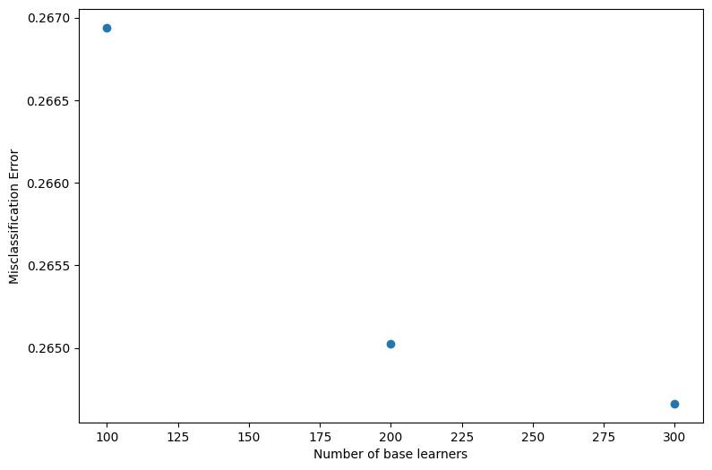

```python
# set figure size
rcParams['figure.figsize'] = 9,6
# plot the error as k-fold increases
error = [1 - x for x in cv_scores]                                              # error corresponds to each number of estimator
optimal_learners = base_ln[error.index(min(error))]                             # optimal number of n_estimator selected by minimum error
plt.scatter(base_ln, error)                                                     # plot number of estimators with corresponding misclassification error
xy = (optimal_learners, min(error))
plt.xlabel("Number of base learners")
plt.ylabel("Misclassification Error")
plt.show()
```

```python
# train the best model
clf_count = RandomForestClassifier(n_estimators = optimal_learners, random_state=42)
clf_count.fit(X_train_count, y_train)
clf_count.score(X_test_count, y_test)
count_predicted = clf_count.predict(X_test_count)
```

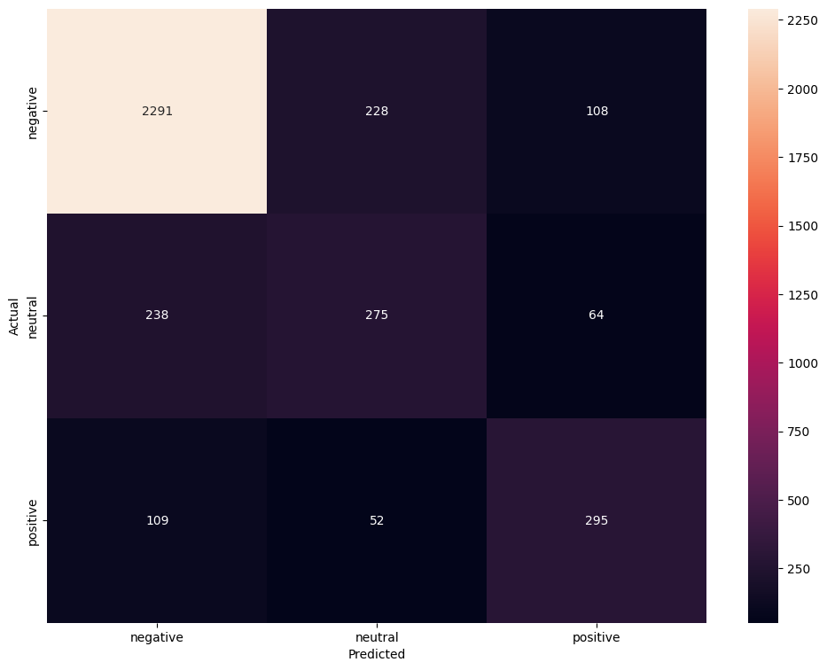

```python
from sklearn.metrics import confusion_matrix
#create confusion matrix for Count Vectorizer
cm_count=confusion_matrix(y_test,count_predicted)

plt.figure(figsize=(12,9))
sns.heatmap(cm_count,annot=True,fmt='d',xticklabels=targets , yticklabels= targets)
plt.xlabel('Predicted')
plt.ylabel('Actual')
plt.show()
```

```python
#import the necessary modules
from sklearn.metrics import precision_score, recall_score, accuracy_score,f1_score

#calculate precision, recall and accuracy using the weighted average
precision = precision_score(y_test, count_predicted,average='micro')
recall = recall_score(y_test, count_predicted,average='micro')
accuracy = accuracy_score(y_test, count_predicted)
f1score=f1_score(y_test,count_predicted,average='micro')
#print the results
print(f'Precision: {precision:.2f}')
print(f'Recall: {recall:.2f}')
print(f'Accuracy: {accuracy:.2f}')
print(f'Accuracy: {f1score:.2f}')
```

```
Precision: 0.78
Recall: 0.78
Accuracy: 0.78
Accuracy: 0.78
```

```python
all_features_count = count_vec.get_feature_names_out()                              # instantiate the features from the vectorizer
top_features_count=[]                                                           # create an empty list for the top 40 features
feat=clf_count.feature_importances_
features=np.argsort(feat)[::-1]
for i in features[0:40]:
    top_features_count.append(all_features_count[i]) # append the feature to the list

print(', '.join(top_features_count)) # print the list of features separated by commas and spaces
```

```
thank, delay, great, love, hours, hold, awesome, cancel, bag, get, hour, amaze, best, fly, wait, please, would, worst, plane, customer, time, call, service, help, fleek, lose, go, make, never, late, need, still, say, miss, flight, try, luggage, tell, fleet, good
```

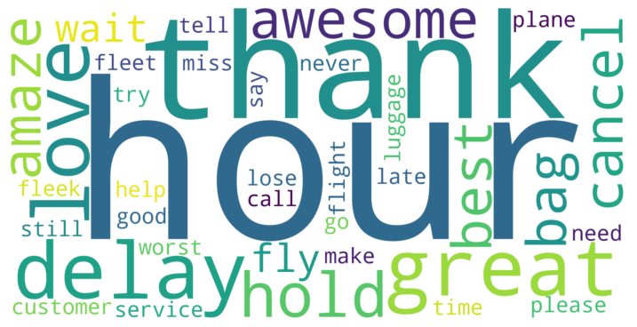

```python
from wordcloud import WordCloud
# create word cloud
wordcloud_count = WordCloud(background_color="white",colormap='viridis',width=2000,
                          height=1000).generate(', '.join(top_features_count)) # join the list of features with commas and spaces

# show word cloud
plt.imshow(wordcloud_count, interpolation='bilinear')
plt.figure(1, figsize=(15, 12), frameon='equal')
plt.axis("off")
plt.show()
```

```python
# saving variables for model
y_train_count = y_train
y_test_count = y_test
```

## Oversampling using count vectorizer

```python
# Import SMOTE from imblearn library
from imblearn.over_sampling import SMOTE

# Create an instance of SMOTE
sm = SMOTE(random_state=42)

# Fit and resample the training data
X_train_smote, y_train_smote = sm.fit_resample(X_train_count, y_train)

# Check the class distribution after resampling
print(y_train_smote.value_counts())
```

```
airline_sentiment
negative    6551
neutral     6551
positive    6551
Name: count, dtype: int64
```

```python
# find the optimal number of base learners using k-fold cross-validation (CV)
base_ln = np.arange(100,400,100).tolist()

# train model with k-fold CV
cv_scores = []
for b in base_ln:
    clf = RandomForestClassifier(n_estimators = b)
    scores = cross_val_score(clf, X_train_smote, y_train_smote, cv = 5, scoring = 'accuracy')
    cv_scores.append(scores.mean())
```

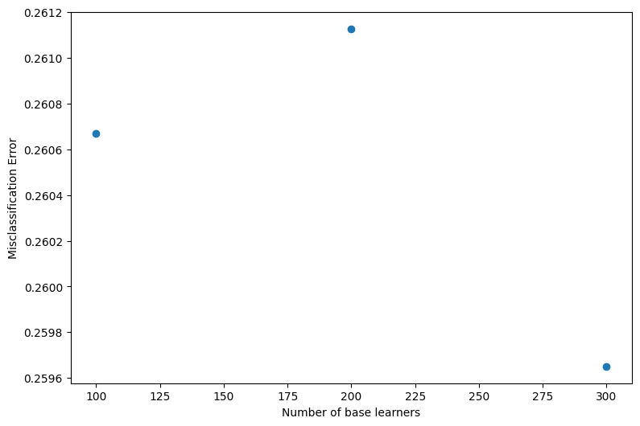

```python
# set figure size
rcParams['figure.figsize'] = 9,6
# plot the error as k-fold increases
error = [1 - x for x in cv_scores]                                              # error corresponds to each number of estimator
optimal_learners = base_ln[error.index(min(error))]                             # optimal number of n_estimator selected by minimum error
plt.scatter(base_ln, error)                                                     # plot number of estimators with corresponding misclassification error
xy = (optimal_learners, min(error))
plt.xlabel("Number of base learners")
plt.ylabel("Misclassification Error")
plt.show()
```

```python
# train the best model
clf_count = RandomForestClassifier(n_estimators = optimal_learners, random_state=42)
clf_count.fit(X_train_smote, y_train_smote)
clf_count.score(X_test_count, y_test)
count_predicted = clf_count.predict(X_test_count)
```

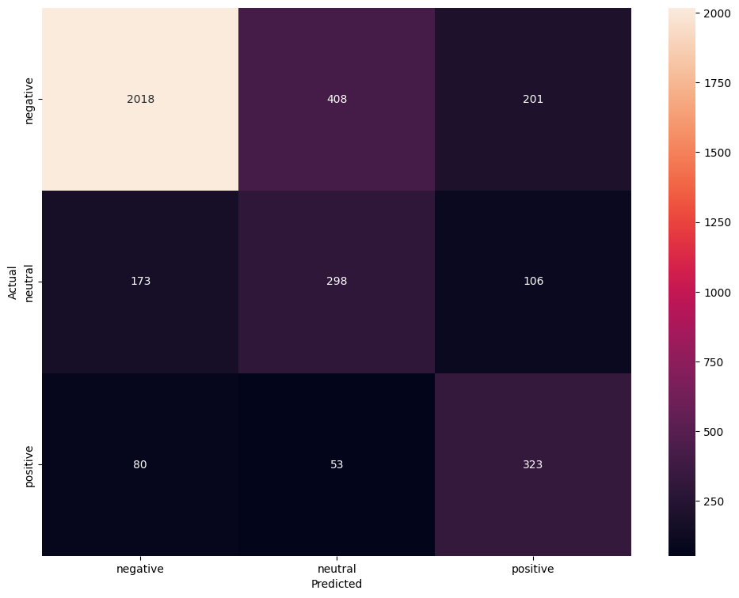

```python
from sklearn.metrics import confusion_matrix
#create confusion matrix for Count Vectorizer
cm_count=confusion_matrix(y_test,count_predicted)

plt.figure(figsize=(12,9))
sns.heatmap(cm_count,annot=True,fmt='d',xticklabels=targets , yticklabels= targets)
plt.xlabel('Predicted')
plt.ylabel('Actual')
plt.show()
```

```python
#calculate precision, recall and accuracy using the weighted average
precision = precision_score(y_test, count_predicted,average='micro')
recall = recall_score(y_test, count_predicted,average='micro')
accuracy = accuracy_score(y_test, count_predicted)
f1score=f1_score(y_test,count_predicted,average='micro')
#print the results
print(f'Precision: {precision:.2f}')
print(f'Recall: {recall:.2f}')
print(f'Accuracy: {accuracy:.2f}')
print(f'Accuracy: {f1score:.2f}')
```

```
Precision: 0.72
Recall: 0.72
Accuracy: 0.72
Accuracy: 0.72
```

Overasampling gives us worse metrics compared to the imbalanced dataset

```python
all_features_count = count_vec.get_feature_names_out()                              # instantiate the features from the vectorizer
top_features_count=[]                                                           # create an empty list for the top 40 features
feat=clf_count.feature_importances_
features=np.argsort(feat)[::-1]
for i in features[0:40]:
    top_features_count.append(all_features_count[i]) # append the feature to the list

print(', '.join(top_features_count)) # print the list of features separated by commas and spaces
```

```
thank, delay, great, love, hold, bag, cancel, hours, hour, get, best, plane, wait, time, awesome, customer, still, worst, try, lose, call, would, late, never, tell, flight, miss, service, make, fly, airline, say, please, luggage, go, need, much, one, gate, issue
```

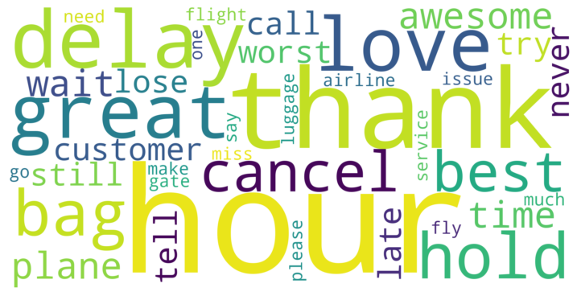

```python
from wordcloud import WordCloud
# create word cloud
wordcloud_count = WordCloud(background_color="white",colormap='viridis',width=2000,
                          height=1000).generate(', '.join(top_features_count)) # join the list of features with commas and spaces

# show word cloud
plt.imshow(wordcloud_count, interpolation='bilinear')
plt.figure(1, figsize=(15, 12), frameon='equal')
plt.axis("off")
plt.show()
```

Using TF-IDF (Term Frequency- Inverse Document Frequency)

- Intialize TFIDF and use it for vectorization
- Store Independent and Dependent variables
- Split the data into train and test
- Build a Random Forest model on train data
- Use Cross validation to validate the score and to find optimal n_estimators
- Plot the misclassification error for each of estimators
- Test the model on testing data
- Plot the Confusion matrix

```python
# set the max number of features at 1000
tfidf_vec = TfidfVectorizer(max_features=1000)
# convert test to numbers with TfidfVectorizer
data_features_idf = tfidf_vec.fit_transform(df_model['text'])
# convert the data features to array
data_features_idf = data_features_idf.toarray()
```

```python
# show shape of the feature vector
data_features_idf.shape
```

```
(14640, 1000)
```

```python
# split data into training and testing set
X_idf = data_features_idf
y = df_model.airline_sentiment
X_train_idf, X_test_idf, y_train, y_test = train_test_split(X_idf, y, test_size=0.25, shuffle=False, random_state=42)
```

```python
# find the optimal number of base learners using k-fold cross-validation (CV)
base_ln = np.arange(100,400,100).tolist()

# train model with k-fold CV
cv_scores = []
for b in base_ln:
    clf = RandomForestClassifier(n_estimators = b)
    scores = cross_val_score(clf, X_train_idf,



                             y_train, cv = 5, scoring = 'accuracy')
    cv_scores.append(scores.mean())
```

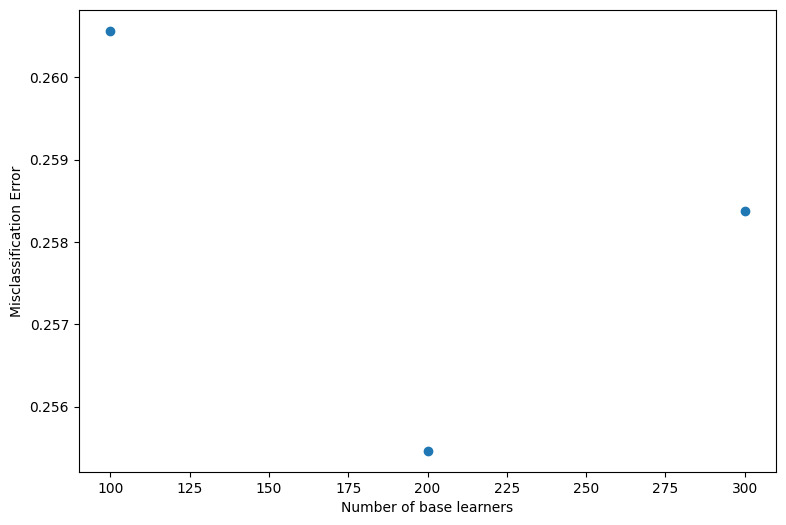

```python
# plot the error as k-fold increases
error = [1 - x for x in cv_scores]                                              # error corresponds to each number of estimator
optimal_learners = base_ln[error.index(min(error))]                             # optimal number of n_estimator selected by minimum error
plt.scatter(base_ln, error)                                                     # plot number of estimators with corresponding misclassification error
xy = (optimal_learners, min(error))
plt.xlabel("Number of base learners")
plt.ylabel("Misclassification Error")
plt.show()
```

```python
# train the best model
clf = RandomForestClassifier(n_estimators = optimal_learners, random_state=42)
clf.fit(X_train_idf, y_train)
clf.score(X_test_idf, y_test)
tf_idf_predicted = clf.predict(X_test_idf)
```

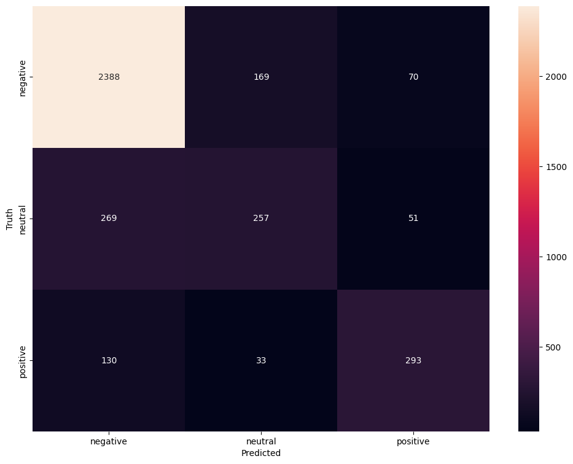

```python
# create confusion matrix for TF-IDF Vectorizer
cm_tfidf=confusion_matrix(y_test , tf_idf_predicted)

plt.figure(figsize=(12,9))
sns.heatmap(cm_tfidf,annot=True,fmt='d',xticklabels=targets , yticklabels=targets)
plt.xlabel('Predicted')
plt.ylabel('Truth')
plt.show()
```

```python
#import the necessary modules
from sklearn.metrics import precision_score, recall_score, accuracy_score

#calculate precision, recall and accuracy using the weighted average
precision = precision_score(y_test,tf_idf_predicted,average='micro')
recall = recall_score(y_test,tf_idf_predicted,average='micro')
accuracy = accuracy_score(y_test, tf_idf_predicted)
f1score=f1_score(y_test,tf_idf_predicted,average='micro')
#print the results
print(f'Precision: {precision:.2f}')
print(f'Recall: {recall:.2f}')
print(f'Accuracy: {accuracy:.2f}')
print(f'Accuracy: {f1score:.2f}')
```

```
Precision: 0.80
Recall: 0.80
Accuracy: 0.80
Accuracy: 0.80
```

```python
all_features_count = tfidf_vec.get_feature_names_out()                              # instantiate the features from the vectorizer
top_features_count=[]                                                           # create an empty list for the top 40 features
feat=clf.feature_importances_
features=np.argsort(feat)[::-1]
for i in features[0:40]:
    top_features_count.append(all_features_count[i]) # append the feature to the list

print(', '.join(top_features_count)) # print the list of features separated by commas and spaces
```

```
thank, delay, great, love, hours, hold, cancel, get, awesome, bag, best, amaze, hour, fly, please, fleek, wait, service, would, time, make, follow, plane, fleet, customer, call, flight, good, help, need, dm, know, worst, go, airline, say, never, lose, still, late
```

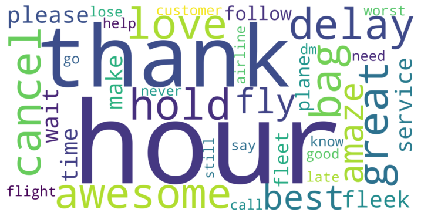

```python
from wordcloud import WordCloud
# create word cloud
wordcloud_count = WordCloud(background_color="white",colormap='viridis',width=2000,
                          height=1000).generate(', '.join(top_features_count)) # join the list of features with commas and spaces

# show word cloud
plt.imshow(wordcloud_count, interpolation='bilinear')
plt.figure(1, figsize=(15, 12), frameon='equal')
plt.axis("off")
plt.show()
```

```python
# saving variables for model
y_train_idf = y_train
y_test_idf = y_test
```

## Oversampling using tf-idf vectorizer

```python
# Import SMOTE from imblearn library
from imblearn.over_sampling import SMOTE

# Create an instance of SMOTE
sm = SMOTE(random_state=42)

# Fit and resample the training data
X_train_smote, y_train_smote = sm.fit_resample(X_train_idf, y_train)

# Check the class distribution after resampling
print(y_train_smote.value_counts())
```

```
airline_sentiment
negative    6551
neutral     6551
positive    6551
Name: count, dtype: int64
```

```python
# find the optimal number of base learners using k-fold cross-validation (CV)
base_ln = np.arange(100,400,100).tolist()

# train model with k-fold CV
cv_scores = []
for b in base_ln:
    clf = RandomForestClassifier(n_estimators = b)
    scores = cross_val_score(clf, X_train_smote,



                             y_train_smote, cv = 5, scoring = 'accuracy')
    cv_scores.append(scores.mean())
```

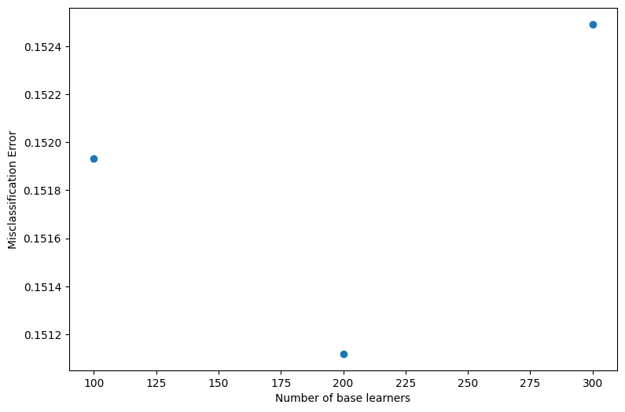

```python
# plot the error as k-fold increases
error = [1 - x for x in cv_scores]                                              # error corresponds to each number of estimator
optimal_learners = base_ln[error.index(min(error))]                             # optimal number of n_estimator selected by minimum error
plt.scatter(base_ln, error)                                                     # plot number of estimators with corresponding misclassification error
xy = (optimal_learners, min(error))
plt.xlabel("Number of base learners")
plt.ylabel("Misclassification Error")
plt.show()
```

```python
# train the best model
clf = RandomForestClassifier(n_estimators = optimal_learners, random_state=42)
clf.fit(X_train_smote, y_train_smote)
clf.score(X_test_idf, y_test)
tf_idf_predicted = clf.predict(X_test_idf)
```

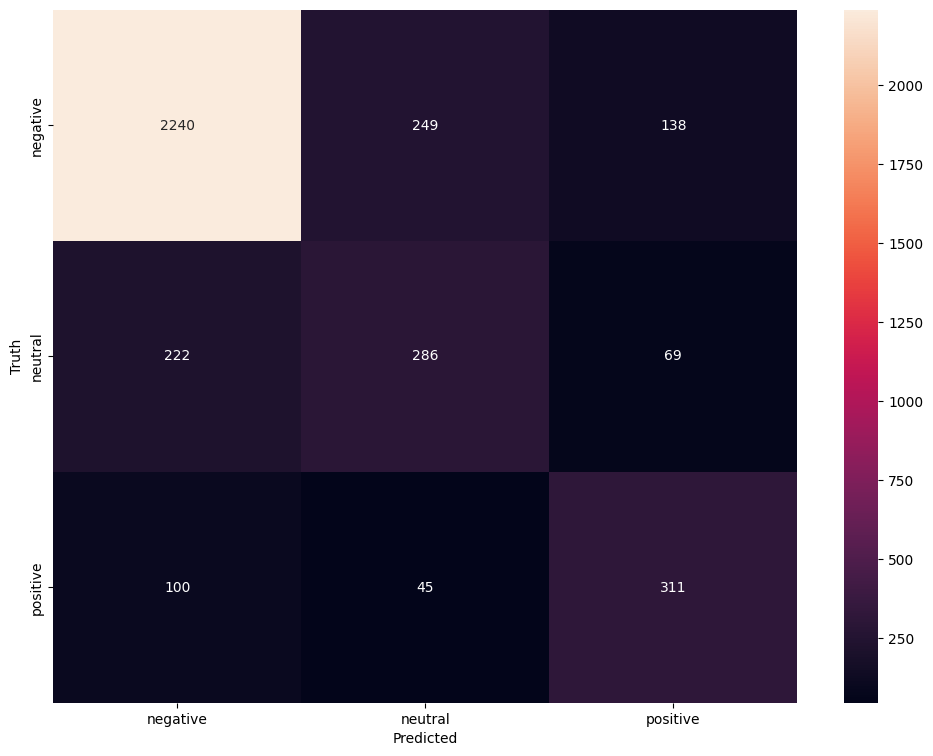

```python
# create confusion matrix for TF-IDF Vectorizer
cm_tfidf=confusion_matrix(y_test , tf_idf_predicted)

plt.figure(figsize=(12,9))
sns.heatmap(cm_tfidf,annot=True,fmt='d',xticklabels=targets , yticklabels=targets)
plt.xlabel('Predicted')
plt.ylabel('Truth')
plt.show()
```

```python
#import the necessary modules
from sklearn.metrics import precision_score, recall_score, accuracy_score

#calculate precision, recall and accuracy using the weighted average
precision = precision_score(y_test,tf_idf_predicted,average='micro')
recall = recall_score(y_test,tf_idf_predicted,average='micro')
accuracy = accuracy_score(y_test, tf_idf_predicted)
f1score=f1_score(y_test,tf_idf_predicted,average='micro')
#print the results
print(f'Precision: {precision:.2f}')
print(f'Recall: {recall:.2f}')
print(f'Accuracy: {accuracy:.2f}')
print(f'Accuracy: {f1score:.2f}')
```

```
Precision: 0.78
Recall: 0.78
Accuracy: 0.78
Accuracy: 0.78
```

The oversampling model performs worse than the imbalanced dataset

```python
all_features_count = tfidf_vec.get_feature_names_out()                              # instantiate the features from the vectorizer
top_features_count=[]                                                           # create an empty list for the top 40 features
feat=clf.feature_importances_
features=np.argsort(feat)[::-1]
for i in features[0:40]:
    top_features_count.append(all_features_count[i]) # append the feature to the list

print(', '.join(top_features_count)) # print the list of features separated by commas and spaces
```

```
thank, great, delay, love, hold, get, cancel, hours, bag, awesome, best, wait, hour, amaze, time, make, service, plane, customer, fly, need, please, would, airline, call, go, try, worst, still, never, say, lose, late, help, flight, good, one, tell, crew, miss
```

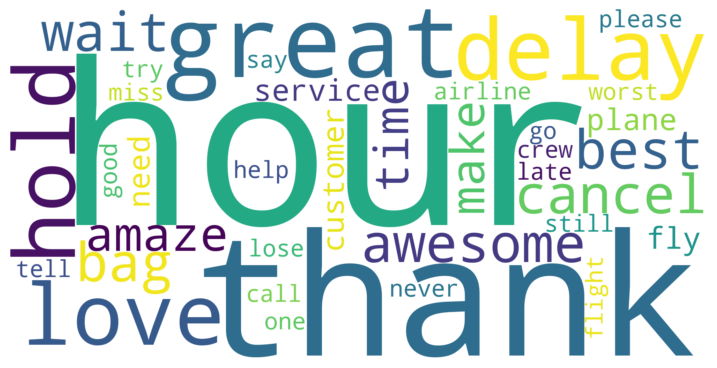

```python
from wordcloud import WordCloud
# create word cloud
wordcloud_count = WordCloud(background_color="white",colormap='viridis',width=2000,
                          height=1000).generate(', '.join(top_features_count)) # join the list of features with commas and spaces

# show word cloud
plt.imshow(wordcloud_count, interpolation='bilinear')
plt.figure(1, figsize=(15, 12), frameon='equal')
plt.axis("off")
plt.show()
```

## Summary

```python
# provide a classification report on the Count Vectorizer model
print("Random Forest model trained with Count Vectorizer data")
print(" ")
print(classification_report(y_test_count , count_predicted, target_names = targets))
print(" ")

# provide a classification report on the TF-IDF Vectorizer model
print("Random Forest model trained with TF-IDF Vectorizer data")
print(" ")
print(classification_report(y_test_idf , tf_idf_predicted, target_names = targets))
print(" ")
```

[output not shown]